# Introduction to ESCO

Jinjin Tian

2020-10-27

# Contents

Welcome to `ESCO`! `ESCO` is an R package for the simple simulation of single-cell RNA sequencing data with special focus on gene co-expression, built using the infrastructure of the `splatter` package. This vignette gives an overview and introduction to ESCO’s functionality.

# 1 Installation

`ESCO` can be download from Github: https://github.com/JINJINT/ESCO

# 2 Overview

We use the term ‘ESCO’ to refer to the newly proposed Ensemble single cell simulator with gene co-expression, and differentiate it from the package SplatterESCO itself. As for the marginal behaviour of genes and cells, the core of the ESCO model is foundimentally the same with the original Splat: they both use a gamma-Poisson distribution with a enforced mean-variance trend to generate gene counts, and use a log-normal/normal distribution to give an expected library size for each cell, while outlier genes (genes with mean expression outside the gamma distribution) and dropouts (random knock out of counts based on mean expression) are introduced along the way.

ESCO can also simulate differential expression between groups of different types of cells or differentiation paths between different cells types where expression changes in a continuous way. These are described further in the ESCO simulation section.

# 3 ESCO simulation

Once we have a set of parameters we are happy with, we can use `escoSimulate` to simulate counts. If we want to make small adjustments to the parameters we can provide them as additional arguments, alternatively if we don’t supply any parameters the defaults will be used:

```r
sim <- escoSimulate(nGenes = 100, nCells  = 50)
```

```
## Getting parameters...
```

```
## Creating simulation object...
```

```
## Simulating library sizes...
```

```
## Sampling from fitted log normal / normal...
```

```
## Simulating gene means...
```

```
## Sampling from fitted gamma...
```

```
## Simulating true counts...
```

```
## Adding technical noise ...
```

```r
sim
```

```
## class: SingleCellExperiment
## dim: 100 50
## metadata(1): Params
## assays(8): Means BaseCellMeans ... Dropout counts
## rownames(100): Gene1 Gene2 ... Gene99 Gene100
## rowData names(5): Gene BaseGeneMean OutlierFactor GeneMean genelen
## colnames(50): Cell1 Cell2 ... Cell49 Cell50
## colData names(2): Cell ExpLibSize
## reducedDimNames(0):
## spikeNames(0):
```

```r
# Access the counts
assays(sim)$TrueCounts[1:5, 1:5]
```

```
##       Cell1 Cell2 Cell3 Cell4 Cell5
## Gene1    17    32    19    21    50
## Gene2     4     2     6     3     5
## Gene3    17     6     4     9    13
## Gene4     5     3     1     0     4
## Gene5    25    14    26     8    63
```

```r
# Information about genes
head(rowData(sim))
```

```
## DataFrame with 6 rows and 5 columns
##           Gene      BaseGeneMean OutlierFactor          GeneMean   genelen
##       <factor>         <numeric>     <numeric>         <numeric> <integer>
## Gene1    Gene1  1.53420876338481             1  1.53420876338481      4997
## Gene2    Gene2 0.275546209967211             1 0.275546209967211      2057
## Gene3    Gene3 0.411105724744821             1 0.411105724744821       550
## Gene4    Gene4 0.163452788090387             1 0.163452788090387      3118
## Gene5    Gene5  1.11318943566506             1  1.11318943566506      1655
## Gene6    Gene6  1.56521087505842             1  1.56521087505842       216
```

```r
# Information about cells
head(colData(sim))
```

```
## DataFrame with 6 rows and 2 columns
##           Cell       ExpLibSize
##       <factor>        <numeric>
## Cell1    Cell1 6961.92106481809
## Cell2    Cell2 7839.40459730769
## Cell3    Cell3 7712.77083372629
## Cell4    Cell4  6180.9995231932
## Cell5    Cell5 11824.4880114313
## Cell6    Cell6 7537.56941372161
```

```r
# Information about paramters
str(metadata(sim)$Params)
```

```
## Formal class 'escoParams' [package "ESCO"] with 57 slots
##   ..@ mean.shape    : num 0.6
##   ..@ mean.rate     : num 0.3
##   ..@ mean.dens     :List of 7
##   .. ..$ x        : num [1:512] -6.24 -6.23 -6.21 -6.19 -6.18 ...
##   .. ..$ y        : num [1:512] 0.00118 0.00133 0.00151 0.00171 0.00193 ...
##   .. ..$ bw       : num 0.383
##   .. ..$ n        : int 10
##   .. ..$ call     : language density.default(x = log(rgamma(10, rate = 0.3, shape = 0.6)))
##   .. ..$ data.name: chr "log(rgamma(10, rate = 0.3, shape = 0.6))"
##   .. ..$ has.na   : logi FALSE
##   .. ..- attr(*, "class")= chr "density"
##   ..@ mean.method   : chr "fit"
##   ..@ lib.loc       : num 9
##   ..@ lib.scale     : num 0.2
##   ..@ lib.norm      : logi FALSE
##   ..@ lib.dens      :List of 7
##   .. ..$ x        : num [1:512] 1840 1868 1896 1923 1951 ...
##   .. ..$ y        : num [1:512] 7.00e-07 7.49e-07 7.99e-07 8.54e-07 9.11e-07 ...
##   .. ..$ bw       : num 1267
##   .. ..$ n        : int 10
##   .. ..$ call     : language density.default(x = rlnorm(10, 9, 0.2))
##   .. ..$ data.name: chr "rlnorm(10, 9, 0.2)"
##   .. ..$ has.na   : logi FALSE
##   .. ..- attr(*, "class")= chr "density"
##   ..@ lib.method    : chr "fit"
##   ..@ out.prob      : num 0.05
##   ..@ out.facLoc    : num 4
##   ..@ out.facScale  : num 0.5
##   ..@ nGroups       : num 1
##   ..@ group.prob    : num 1
##   ..@ deall.prob    : num 0.3
##   ..@ de.prob       : num 0.1
##   ..@ de.quantile   : num 0.7
##   ..@ de.downProb   : num 0.5
##   ..@ de.facLoc     : num 0.1
##   ..@ de.facScale   : num 0.7
##   ..@ de.rank       : list()
##   ..@ de.facrank    : list()
##   ..@ paths.deprob  : num 0.2
```

[output cut: 26 more lines]

```
##   ..@ lenslope      : num 0.02
##   ..@ nbins         : num 20
##   ..@ amp_bias_limit: num [1:2] -0.2 0.2
##   ..@ rate_2PCR     : num 0.8
##   ..@ nPCR1         : num 16
##   ..@ nPCR2         : num 10
##   ..@ LinearAmp     : logi FALSE
##   ..@ LinearAmp_coef: num 2000
##   ..@ depth_mean    : num 1e+05
##   ..@ depth_sd      : num 1500
##   ..@ dirname       : chr ""
##   ..@ trials        : num 1
##   ..@ nGenes        : num 100
##   ..@ nCells        : num 50
##   ..@ seed          : int 161790
```

Looking at the output of `escoSimulate` we can see that `sim` is `SingleCellExperiment` object contains phenotype information about each cell (accessed using `colData`); feature information about each gene (accessed using `rowData`); genes by cells data matrix and intermediate values of the simulation (accessed using `assays`); and parameters used to generate this simulation (accessed using `metadata`).

The main part of this object is a series of features by samples matrix containing the simulated true counts (accessed using `assays(sim)$TrueCounts`); counts with zero-inflation noise; (accessed using `assays(sim)$counts`); counts with downsample noise ((accessed using `assays(sim)$observedcounts`). By default, all three kinds of data matrix will be simulated, while users are allowed to simulated only one or two of them for time/space saving, via specifying the `dropout.type` in parameters setting.

For more details about the `SingleCellExperiment` object refer to the [vignette](https://bioconductor.org/packages/devel/bioc/vignettes/SingleCellExperiment/inst/doc/intro.html). For information about what you can do with `scater` refer to the `scater` documentation and [vignette](https://bioconductor.org/packages/release/bioc/vignettes/scater/inst/doc/vignette.html).

Additionally, in order to have better reproducibility, ESCO also allows multiple trials of noisy data generated from one common true counts in one single call, and save them seperately in the directory user provided. The returned `sim` on the other hand will only contain one trial of noisy data in order to avoid memory exhuastion.

```r
if(!dir.exists(paste0(showdir,"case1")))
  dir.create(paste0(showdir,"case1"))
sim <- escoSimulate(nGenes = 100, nCells  = 50,
                    trials = 2,
                    dirname = paste0(showdir,"case1/"),
                    verbose = FALSE)
list.files(path = paste0(showdir,"case1/"), full.names = FALSE)
```

```
## [1] "1depme1e+05_alphame0.3_Raw.rds" "1dm1_Raw.rds"
## [3] "2depme1e+05_alphame0.3_Raw.rds" "2dm1_Raw.rds"
## [5] "sim.rds"                        "True.rds"
```

Moreover, ESCO also allows noisy data of different configuration of noise level data generated from one common true counts in one single call, and save them seperately in the directory user provided. The returned `sim` on the other hand will only contain one configuration of noisy data in order to avoid memory exhuastion.

```r
if(!dir.exists(paste0(showdir,"case2")))dir.create(paste0(showdir,"case2"))
sim <- escoSimulate(nGenes = 100, nCells  = 50,
                    dropout.mid = c(1,2),
                    alpha_mean = c(0.1, 0.2),
                    trials = 2,
                    dirname = paste0(showdir,"case2/"),
                    verbose = FALSE)
list.files(path = paste0(showdir,"case2/"), full.names = FALSE)
```

```
##  [1] "1depme1e+05_alphame0.1_Raw.rds" "1depme1e+05_alphame0.2_Raw.rds"
##  [3] "1dm1_Raw.rds"                   "1dm2_Raw.rds"
##  [5] "2depme1e+05_alphame0.1_Raw.rds" "2depme1e+05_alphame0.2_Raw.rds"
##  [7] "2dm1_Raw.rds"                   "2dm2_Raw.rds"
##  [9] "sim.rds"                        "True.rds"
```

## 3.1 Simulating one cell group

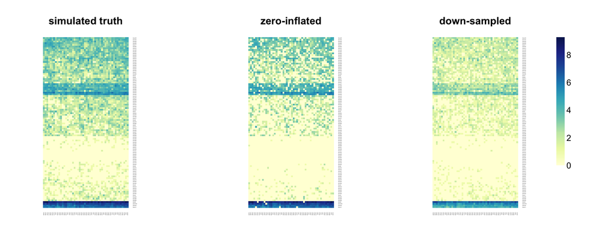

```r
sim <- escoSimulateSingle(nGenes = 100, nCells = 50,
                          lib.loc = 7, withcorr = TRUE, verbose = FALSE)

# get the data
datalist = list("simulated truth" = assays(sim)$TrueCounts,
                "zero-inflated" = assays(sim)$counts,
                "down-sampled" = assays(sim)$observedcounts)

# plotting the data
heatdata(datalist, norm = FALSE, size = 2, ncol = 3)
```

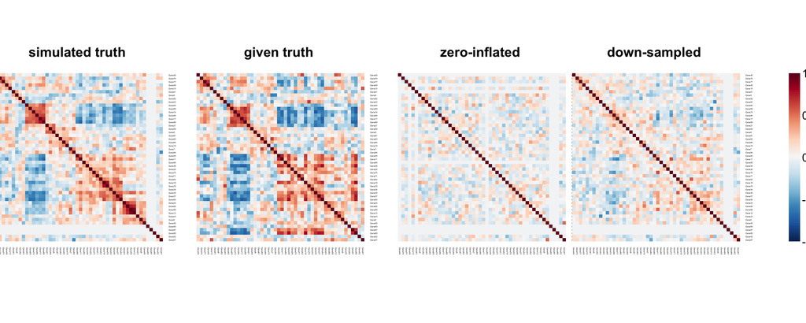

```r
# plotting the GCN
rholist = metadata(sim)$Params@corr
corrgenes = rownames(rholist[[1]])
gcnlist = lapply(datalist, function(data)gcn(data, genes = corrgenes))
gcnlist = append(gcnlist, list("given truth" = rholist[[1]]), 1)
heatgcn(gcnlist, size = 3, ncol = 4)
```

You can also provide your own defined GCN. In the following, we take the randomly generated correlation structure in the last simulation as our input.

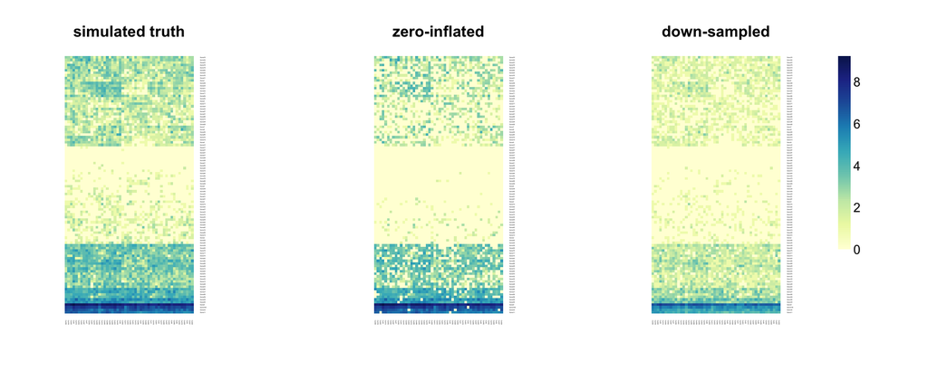

```r
sim <- escoSimulateSingle(nGenes = 100, nCells = 50,
                          lib.loc = 7, withcorr = TRUE,
                          corr = rholist, verbose = FALSE)

# plotting the data
datalist = list("simulated truth" = assays(sim)$TrueCounts,
              "zero-inflated" = assays(sim)$counts,
              "down-sampled" = assays(sim)$observedcounts)
heatdata(datalist, norm = FALSE, size = 2, ncol = 3)
```

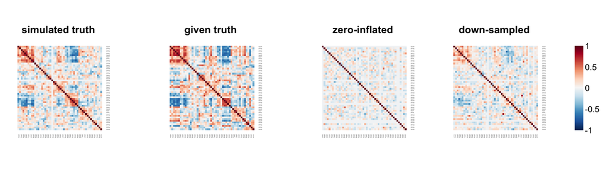

```r
# plotting the GCN
rholist = metadata(sim)$Params@corr
corrgenes = rownames(rholist[[1]])
gcnlist = lapply(datalist, function(data)gcn(data, genes = corrgenes))
gcnlist = append(gcnlist, list("given truth" = rholist[[1]]), 1)
heatgcn(gcnlist, size = 2, ncol = 4)
```

## 3.2 Simulating multiple discrete groups

So far we have only simulated a single population of cells but often we are interested in investigating a mixed population of cells and looking to see what cell types are present or what differences there are between them. ESCO is able to simulate these situations by changing the `method` argument. Here we are going to simulate two groups, by specifying the `group.prob`, `de.prob` parameters. The gene-gene correlation can be generated randomly (by default), or given by users.

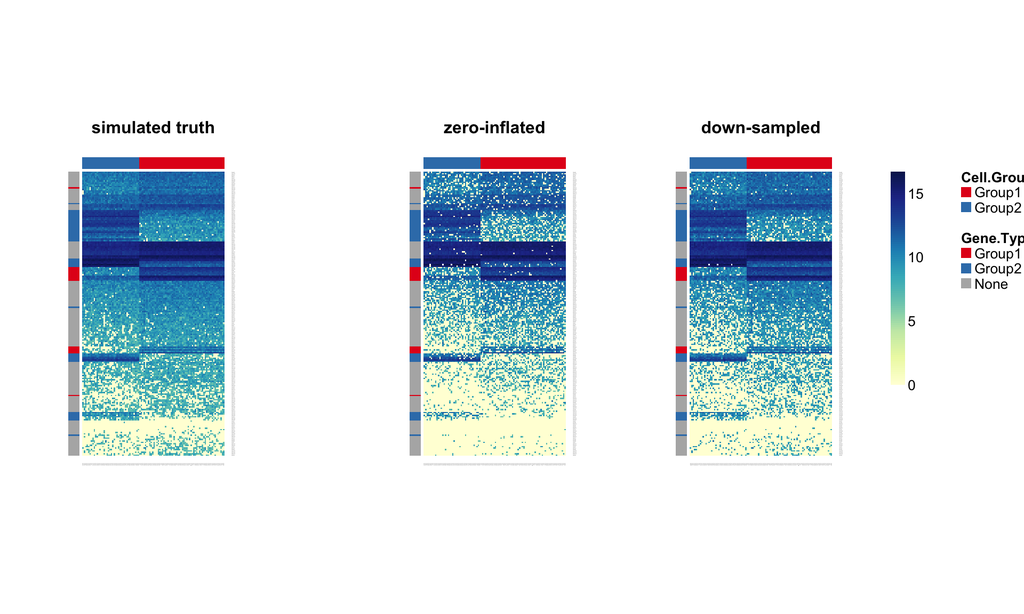

```r
sim<-escoSimulateGroups(nGenes = 200, nCells = 100,
                        group.prob = c(0.6, 0.4), deall.prob = 0.3,
                        de.prob = c(0.3, 0.7),
                        de.facLoc = c(1.9, 2.5), withcorr = TRUE,
                        trials = 1, verbose =FALSE)

# organize the marker gene info
genegroup = paste0("Group", rowData(sim)$GeneGroup)
genegroup[which(genegroup=="Group0")] = "None"
geneinfo = data.frame(genes = rowData(sim)$Gene,
                      newcelltype = as.factor(genegroup))

# organize the cell info
cellinfo = data.frame(çells = colData(sim)$Cell,
                       newcelltype= as.factor(colData(sim)$Group))

# get the data
datalist = list("simulated truth" = assays(sim)$TrueCounts,
                "zero-inflated" = assays(sim)$counts,
                "down-sampled" = assays(sim)$observedcounts)

# plotting the data
heatdata(datalist, cellinfo = cellinfo, geneinfo = geneinfo,
         size = 1, ncol = 3)
```

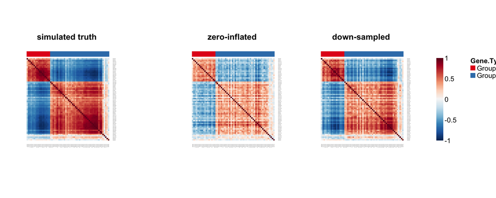

```r
# plot GCN for all marker genes (i.e. DE genes) across all cell groups
degeneinfo = geneinfo[which(geneinfo$newcelltype!="None"),]
degeneinfo$newcelltype = droplevels(degeneinfo$newcelltype)
degcnlist = lapply(datalist, function(data)gcn(data, genes = degeneinfo$genes))
heatgcn(degcnlist, geneinfo = degeneinfo, size = 2, ncol = 3)
```

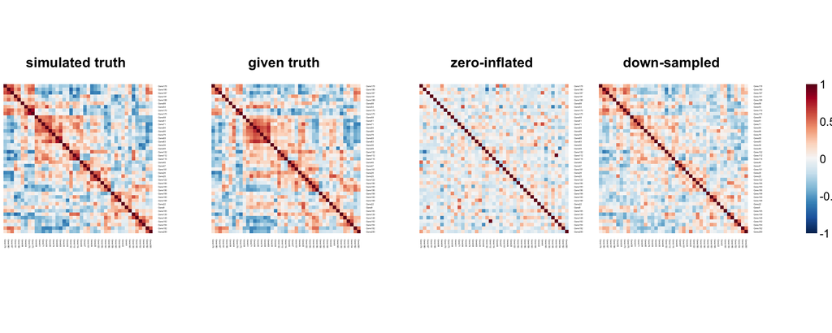

```r
# plot GCN for marker gene within one cell group
rholist = metadata(sim)$Params@corr
group2_gcnlist = lapply(datalist,
                        function(data){
                          gcn(data[,which(colData(sim)$Group=="Group2")],
                              CPM2 = TRUE,
                              genes = rownames(rholist[["Group2"]]))})
group2_gcnlist = append(group2_gcnlist,
                        list("given truth" = rholist[["Group2"]]), 1)
heatgcn(group2_gcnlist, size = 3, ncol = 4)
```

## 3.3 Simulating tree structured cell group

```r
#generate the tree
yaml="
    name: All
    Group1:
        Group1-1:
             params: NULL
    Group2:
        Group2-1:
             params: NULL
        Group2-2:
             params: NULL
"
os.list = yaml::yaml.load(yaml)
tree = data.tree::as.Node(os.list)
tree = data.tree::as.phylo.Node(tree)
```

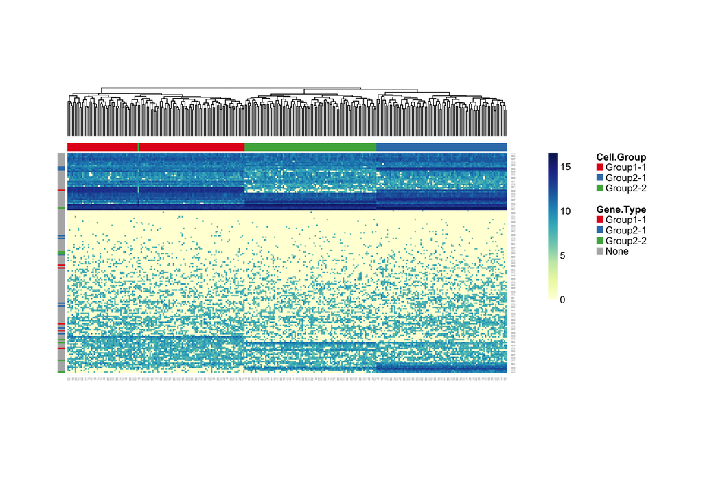

```r
# simulation
sim<-escoSimulateTree(nGenes = 500, nCells = 300,
                      tree = list(tree),
                      group.prob = c(0.4, 0.3, 0.3),
                      deall.prob = 0.3,
                      de.center = 2,
                      de.prob = c(0.5, 0.5, 0.5),
                      de.facLoc = c(1.5, 2, 3),
                      de.facScale = c(0.9, 0.9, 0.9),
                      withcorr = TRUE,
                      trials = 1, verbose = FALSE)
# get the data
datatrue = assays(sim)$TrueCounts

# get the cellinfo
cellinfo  = data.frame(cell = colData(sim)$Cell,
                       newcelltype = as.factor(colData(sim)$Group))
levels(cellinfo$newcelltype) = tree$tip.label

# get the geneinfo
genegroup = paste0("Group", rowData(sim)$GeneGroup)
genegroup[which(genegroup=="Group0")] = "None"
geneinfo = data.frame(genes = rowData(sim)$Gene,
                      newcelltype = as.factor(genegroup))
levels(geneinfo$newcelltype)[1:3] = tree$tip.label

# get the DE geneinfo
groups <- colData(sim)$Group
group.names <- sort(unique(groups))
group.facs.gene <- rowData(sim)[, paste0("DEFac", group.names)]
DEgene.name = as.character(rowData(sim)$Gene[which(group.facs.gene[,1]>1)])
degeneinfo = geneinfo[match(DEgene.name, geneinfo$genes),]

# plot the data
heatdata(list(datatrue),
         colv = TRUE,
         cellinfo = cellinfo,
         geneinfo = degeneinfo,
         genes = degeneinfo$genes,
         size = 1.5, ncol = 1)
```

## 3.4 Simulating continous cell trajectory

The other situation that is often of interest is a differentiation process where one cell type is changing into another. escoter approximates this process by simulating a series of steps between two groups and randomly assigning each cell to a step. We can create this kind of simulation using the `"paths"` method.

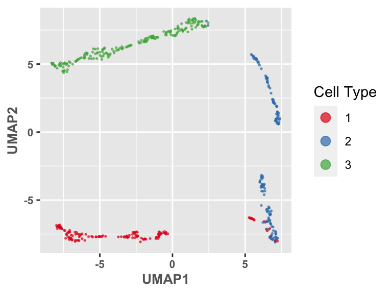

```r
sim <- escoSimulateTraj(nGenes = 1000, nCells = 500,
                        paths.deprob = 0.3,
                        paths.design = data.frame(
                          Path = c(1, 2, 3),
                          From = c(0, 1, 2),
                          Steps = c(100, 100, 100)
                        ),
                        cells.design = data.frame(
                          Path = c(1, 2, 3),
                          Probability = c(0.3, 0.3, 0.4),
                          Alpha = 1,
                          Beta = 1
                        ),
                        withcorr = TRUE,verbose = FALSE)


datatrue = assays(sim)$TrueCounts

# get the cellinfo
cellinfo = data.frame(cell = colData(sim)$Cell,
                      newcelltype = colData(sim)$Path)
# get the pesudo time
celltime = data.frame(path = as.numeric(colData(sim)$Path),
                      step = as.numeric(colData(sim)$Step))
celltime = order(celltime[,1], celltime[,2])

# get the geneinfo
degenes = which(metadata(sim)$Params@paths.DEgenes==1)

# plot the data
umapplot(t(t(datatrue)/colSums(datatrue)),
         celltype  = colData(sim)$Path,
         labels = levels(as.factor(colData(sim)$Path)))
```

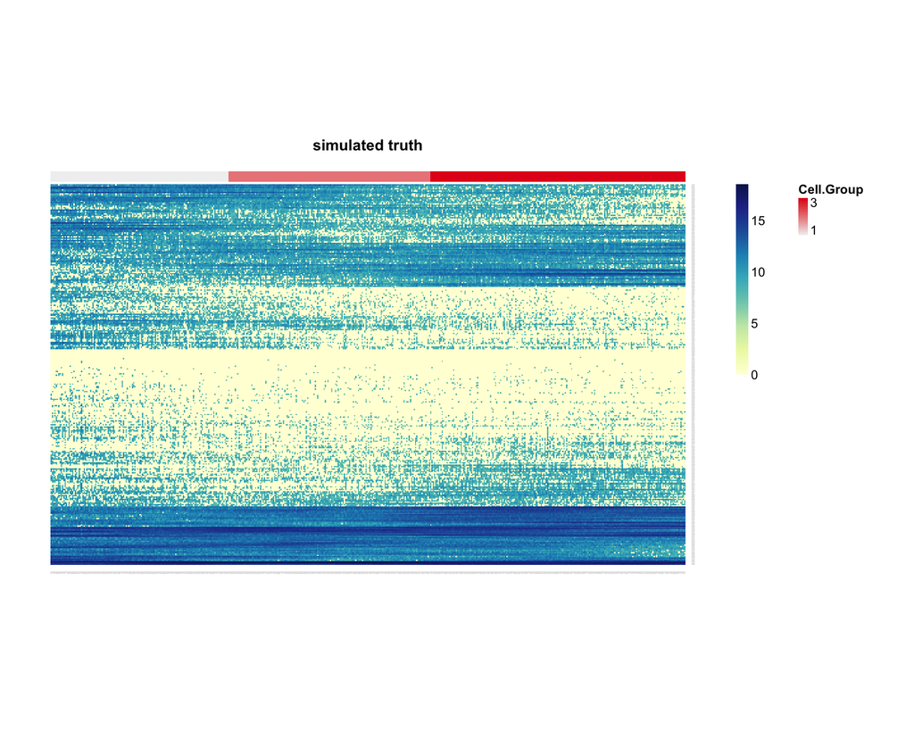

```r
heatdata(list("simulated truth" = datatrue[degenes,]),
         cellinfo = cellinfo,
         colv = celltime, size = 1, ncol = 1)
```

# 4 GCN comparison

The new package also provide simple function to compare the GCN of a list of data, using the first one in the list as the benchmark. You can choose different correlation metric; error metric; clustering method etc.

```r
gcnerr = evaluation(datalist, genes, cells,
                    corrname = c("pearson", "spearman"),
                    CPM2  = CPM2, errname = c("MSE", "ARI", "AUC"),
                    clustk = c(2:9), clustmethod = "hclust")
```